# Generate missing values with ampute

### `cont == TRUE`

When argument `cont` is set to `TRUE`, we use argument `type` to choose between the four logistic distribution functions. Figure 3 shows these four types.

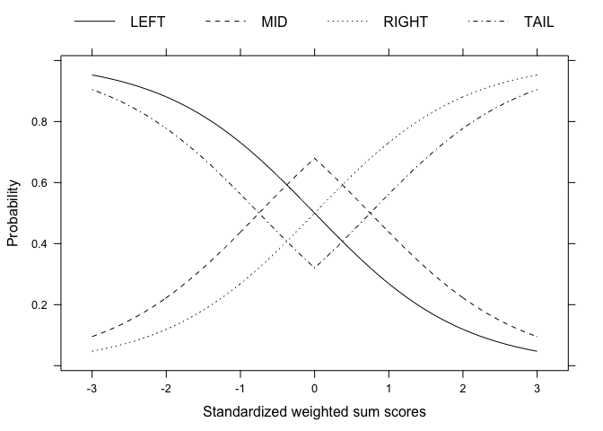

In `ampute`, the logistic distribution functions are applied to the weighted sum scores. For instance, in the situation of RIGHT missingness, cases with high weighted sum scores will have a higher probability to have missing values, compared to cases with low weighted sum scores. With a left-tailed (LEFT), centered (MID) or both-tailed (TAIL) missingness type, higher probability values are given to the candidates with low, average or extreme weighted sum scores respectively.

For each pattern, a different missingness type can be chosen. In our example, we have four patterns, so four type specifications are required. It is advised to inspect the result with `bwplot` (below, this is done for pattern 2), although the scatterplots give insight as well (as an example, we show a plot for pattern 4).

```r
result <- ampute(testdata, freq = c(0.7, 0.1, 0.1, 0.1), patterns = mypatterns, weights = myweights, cont = TRUE, type = c("RIGHT", "TAIL", "MID", "LEFT"))
```

```
## $`Boxplot pattern 2`
```

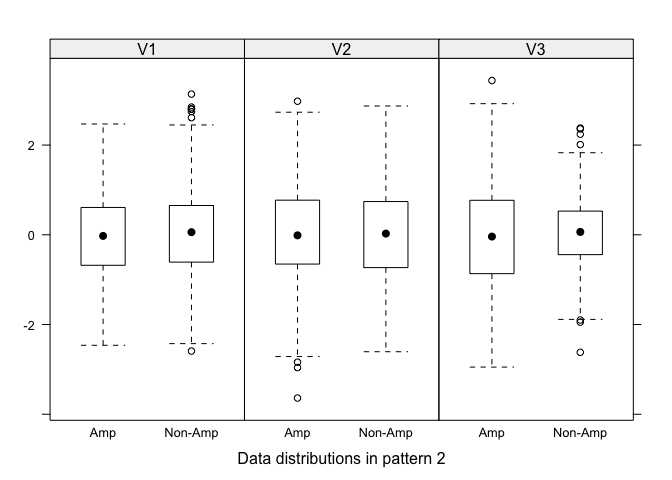

```r
bwplot(result, which.pat = 2, descriptives = FALSE)
```

From the boxplots of pattern 2, it becomes visible that the interquartile range (IQR) is much larger for the amputed V3 values compared to the non-amputed data. This is due to the fact that in pattern 2 only V3 defines the missingness. Besides, we requested a TAIL missingness type, which means that all cases with values at the tails of the distribution of the weighted sum scores (based on merely V3), will be made missing.

```
## $`Scatterplot Pattern 4`
```

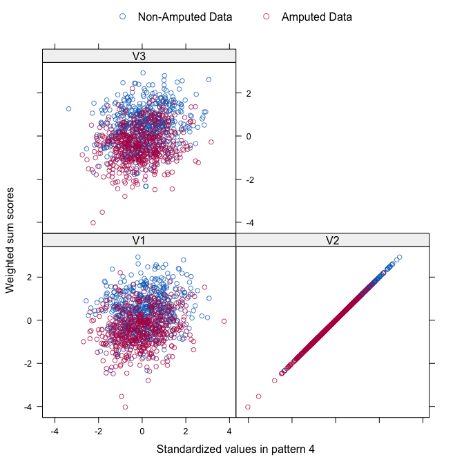

```r
xyplot(result, which.pat = 4)
```

First, notice that there are much fewer dots in these scatterplots compared to the scatterplots we saw earlier. This is due to the `freq` setting: we specified that only 10 percent of the cases with missing values should have missingness pattern 4. Second, the scatterplots show that all the amputed data are at the left hand side of the weighted sum scores due to the `"LEFT"` setting in the `type` argument. Third, these figures show that there is a perfect relation between variable V2 and the weighted sum scores. Clearly, pattern 4 depends on variable V2 only, which we can remember from the `weights` matrix we used.

```r
result$weights
```

```
##   V1  V2  V3
## 1  0 0.8 0.4
## 2  0 0.0 1.0
## 3  3 1.0 0.0
## 4  0 1.0 0.0
```

### `cont == FALSE`

When argument `cont` is set to `FALSE`, we use argument `odds` to define the probability values manually. The specification of odds values occurs in two steps. First, we divide each subset into a certain number of equally sized groups. The number of groups can differ between patterns. Second, for each group within a pattern, an odds value defines the relative probability of having missing values.

Let us have a look at the working of these odds values. The default `odds` matrix is as follows:

```r
myodds <- result$odds
myodds
```

```
##      [,1] [,2] [,3] [,4]
## [1,]    1    2    3    4
## [2,]    1    2    3    4
## [3,]    1    2    3    4
## [4,]    1    2    3    4
```

This `odds` matrix specifies that the candidates of each pattern are divided into four groups, since each pattern (each row) consists of four values. Furthermore, the values `c(1, 2, 3, 4)` indicate that a case with a weighted sum score in the highest quantile will have a probability of having missing values that is four times higher than a candidate with a weighted sum score in the lowest quantile. In Figure 4 the different probabilities that belong to this setting are shown for 100 candidates of pattern 1.

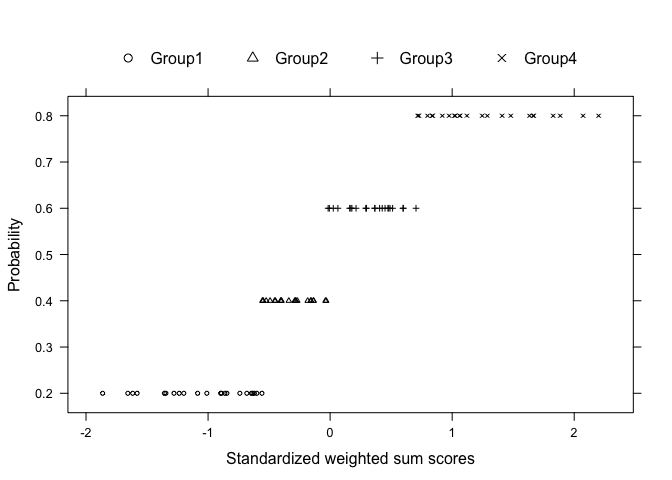

As can be seen, there are indeed four groups in pattern 1. The groups have an approximately equal size, with each a certain probability to obtain missing values. The probability of group 4 is indeed four times as large as the probability of group 1.

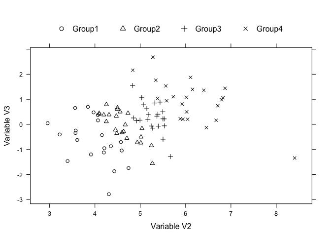

Let us now dig deeper into the contents of the `odds` matrix. The #rows of this matrix are equal to #patterns. The #columns are defined by the user and depend on the desired amputation procedure. The cells in the `odds` matrix that are not used should be filled with NAs. Let us define the following matrix:

```r
myodds[3, ] <- c(1, 0, 0, 1)
myodds[4, ] <- c(1, 1, 2, 2)
myodds <- cbind(myodds, matrix(c(NA, NA, NA, 1, NA, NA, NA, 1), nrow = 4, byrow = F))
myodds
```

```
##      [,1] [,2] [,3] [,4] [,5] [,6]
## [1,]    1    2    3    4   NA   NA
## [2,]    1    2    3    4   NA   NA
## [3,]    1    0    0    1   NA   NA
## [4,]    1    1    2    2    1    1
```

We keep the default setting of the first two patterns. Then, for pattern 3, the weighted sum scores will be divided into four groups. The odds values mean that candidates with low weighted sum scores will have a probability to be missing that is equal to the probability of candidates with high weighted sum scores. However, candidates with weighted sum scores around average will not be made missing. Because pattern 3 depends on variable V1 with a weight of 3 and on variable V2 with a weight of 1, the effect will be most visible for variable V1.

The weighted sum scores of the fourth pattern will be divided into six groups. All candidates will have a probability of having missing values, but this probability is larger for candidates with weighted sum scores around average.

```r
result <- ampute(testdata, freq = c(0.7, 0.1, 0.1, 0.1), patterns = mypatterns,
                 weights = myweights,cont = FALSE, odds = myodds, prop = 0.3)
```

```
## $`Boxplot pattern 3`
```

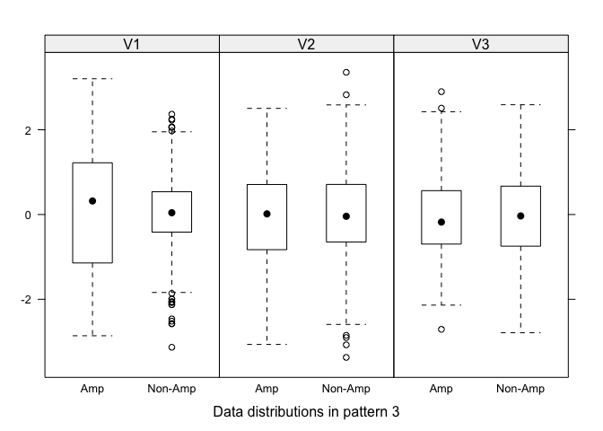

```
##
## $`Boxplot pattern 4`
```

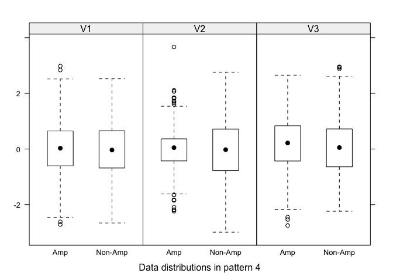

```r
bwplot(result, which.pat = c(3, 4), descriptives = FALSE)
```

In the boxplots of pattern 3, it is visible that the IQR for the amputed data is larger than for the non-amputed data. This is especially the case for variable V1, a bit less for variable V2 and almost absent for variable V3.

In pattern 4, the effect of the specifications is only visible for variable V2, because the other variables are made missing. In contrast to pattern 3, the amputation is performed in the center of the weighted sum scores, resulting to a MID-like missingness pattern.

### 3. Additional features of `ampute`

`ampute` contains the functions `bwplot` and `xyplot` to investigate the behaviour of the missingness. As discussed, `ampute` can generate MCAR, MAR and MNAR missingness. A combination of MAR and MNAR missingness can be generated by changing the `weights` matrix. The following command, for instance, generates MAR missingness in pattern 1 and MNAR missingness in pattern 2. As a result, the incomplete dataset will contain both type of missingness mechanisms.

```r
result <- ampute(testdata, freq = c(0.7, 0.3), patterns = c(0, 0, 1, 0, 1, 0), weights = c(0, 0, 1, 1, 0, 1))
```

Unfortunately, the generation of both MCAR and MAR (or any form of weak MAR missingness) is not yet directly possible. By running the function twice, however, the desired combination of mechanisms can still be obtained. For example:

```r
ampdata1 <- ampute(testdata, patterns = c(0, 1, 1), prop = 0.2, mech = "MAR")$amp
ampdata2 <- ampute(testdata, patterns = c(1, 1, 0), prop = 0.8, mech = "MCAR")$amp

indices <- sample(x = c(1, 2), size = nrow(testdata), replace = TRUE,
                  prob = c(1/2, 1/2))

ampdata <- matrix(NA, nrow = nrow(testdata), ncol = ncol(testdata))
ampdata[indices == 1, ] <- as.matrix(ampdata1[indices == 1, ])
ampdata[indices == 2, ] <- as.matrix(ampdata2[indices == 2, ])

md.pattern(ampdata)
```

```
##      [,1] [,2] [,3] [,4]
## 5072    1    1    1    0
##  990    1    0    1    1
## 3938    1    1    0    1
##         0  990 3938 4928
```

##### Class `mads`

The return object from `ampute` is of class `mads`. `mads` contains the amputed dataset, the function specifications and some extra objects that might be useful.

```r
names(result)
```

```
##  [1] "call"     "prop"     "patterns" "freq"     "mech"     "weights"
##  [7] "cont"     "type"     "odds"     "amp"      "cand"     "scores"
## [13] "data"
```

The object `cand` is a vector that contains for every case the missing data pattern it was candidate for.

```r
result$cand[1:30]
```

```
##  [1] 1 2 1 1 2 1 1 1 1 2 1 1 1 1 1 1 1 1 2 1 2 1 1 1 1 2 1 1 2 1
```

The object `scores` is a list with, for each pattern, the weighted sum scores of the candidates.

```r
result$scores[[1]][1:10]
```

```
##          1          3          4          6          7          8
##  0.3642853  0.1774016  0.2091449 -0.2610135  1.4343838  0.6914479
##          9         11         12         13
## -1.0476095  0.8364393  0.1252278 -0.4240388
```

Furthermore, the object `data` contains the original data.

```r
head(result$data)
```

```
##          V1       V2         V3
## 1 10.487466 6.018999  0.3681981
## 2  9.668991 4.391821 -1.1127595
## 3 10.273415 4.662521  0.1796964
## 4 10.124800 4.055544  0.2117145
## 5 11.835097 7.171578  1.7141378
## 6 10.803311 5.038649 -0.2625144
```

##### Argument `run`

For large datasets or slow computers, it might be desirable to specify the needed matrices before performing the amputation right away. When the argument `run` is set to `FALSE`, all results will be stored in the `mads` object except for the amputed dataset. As a result, the default settings for the `patterns`, `weights` or `odds` argument can be changed easily and entered into a new run (with `run == TRUE`).

```r
emptyresult <- ampute(testdata, run = FALSE)
emptyresult$amp
```

```
## data frame with 0 columns and 0 rows
```

## Go ahead and `ampute`!

### References

Brand, J.P.L. (1999). *Development, implementation and evaluation of multiple imputation strategies for the statistical analysis of incomplete data sets* (pp. 110-113). Dissertation. Rotterdam: Erasmus University.

Van Buuren, S. (2012). *Flexible imputation of missing data* Boca Raton, FL.: Chapman & Hall/CRC Press.

Schouten, R.M., Lugtig, P.L., and Vink, G. (2017) *Generating missing values for simulation purposes: A multivariate amputation procedure* Under review. Available from: https://github.com/RianneSchouten/Amputation_with_Ampute/blob/master/Manuscript%20article/Manuscript.pdf